12/30/2021

## Necessary libraries

Load necessary libraries

```r
library(tidyverse)
library(dplyr)
library(dlookr)
library(rnoaa)
library(lubridate)
require(devtools)
library(zoo)
library(data.table)
library(ggplot2)
library(cluster)
library(fpc)
library(factoextra)
```

## Data importing, cleaning and pre-processing

Read the data

First understanding of the data

```r
fires_train
```

```
## # A tibble: 10,309 × 21
##       id region              district  municipality  parish   lat   lon   origin
##    <dbl> <chr>               <chr>     <chr>         <chr>    <chr> <chr> <chr>
##  1     1 Trás-os-Montes      Bragança  Bragança      Zoio     41º4… 6º53… firep…
##  2     2 <NA>                Viseu     Oliveira de … União d… 40º4… 8º14… firep…
##  3     3 Entre Douro e Minho Aveiro    Vale de Camb… Roge     40º5… 8º19… firep…
##  4     4 Trás-os-Montes      Viseu     Lamego        Várzea … 41º4… 7º46… firep…
##  5     5 Entre Douro e Minho Braga     Terras de Bo… Rio Cal… 41º4… 8º13… firep…
##  6     6 Beira Interior      Castelo … Sertã         Trovisc… 39º5… 7º58… firep…
##  7     7 Entre Douro e Minho Viana do… Ponte de Lima Refóios… 41º4… 8º32… firep…
##  8     8 <NA>                Vila Real Boticas       Alturas… 41º3… 7º52… fire
##  9     9 <NA>                Braga     Barcelos      União d… 41º3… 8º38… fire
## 10    10 Beira Litoral       Aveiro    Anadia        Avelãs … 40:2… 08:2… firep…
## # … with 10,299 more rows, and 13 more variables: alert_date <dttm>,
## #   alert_hour <time>, extinction_date <dttm>, extinction_hour <time>,
## #   firstInterv_date <dttm>, firstInterv_hour <time>, alert_source <lgl>,
## #   village_area <dbl>, vegetation_area <dbl>, farming_area <dbl>,
## #   village_veget_area <dbl>, total_area <dbl>, intentional_cause <dbl>
```

```r
summary(fires_train)
```

```
##        id           region            district         municipality
##  Min.   :    1   Length:10309       Length:10309       Length:10309
##  1st Qu.: 2578   Class :character   Class :character   Class :character
##  Median : 5155   Mode  :character   Mode  :character   Mode  :character
##  Mean   : 5155
##  3rd Qu.: 7732
##  Max.   :10309
##
##     parish              lat                lon               origin
##  Length:10309       Length:10309       Length:10309       Length:10309
##  Class :character   Class :character   Class :character   Class :character
##  Mode  :character   Mode  :character   Mode  :character   Mode  :character
##
##
##
##
##    alert_date                   alert_hour       extinction_date
##  Min.   :2014-01-09 00:00:00   Length:10309      Min.   :2014-01-09 00:00:00
##  1st Qu.:2014-09-06 01:00:00   Class1:hms        1st Qu.:2014-09-06 07:00:00
##  Median :2015-05-20 01:00:00   Class2:difftime   Median :2015-05-20 01:00:00
##  Mean   :2015-03-14 08:23:02   Mode  :numeric    Mean   :2015-03-14 11:05:53
##  3rd Qu.:2015-08-01 01:00:00                     3rd Qu.:2015-08-01 01:00:00
##  Max.   :2015-12-27 00:00:00                     Max.   :2015-12-27 00:00:00
##                                                  NA's   :11
##  extinction_hour   firstInterv_date              firstInterv_hour
##  Length:10309      Min.   :2014-01-09 00:00:00   Length:10309
##  Class1:hms        1st Qu.:2014-09-07 01:00:00   Class1:hms
##  Class2:difftime   Median :2015-05-20 01:00:00   Class2:difftime
##  Mode  :numeric    Mean   :2015-03-14 11:52:27   Mode  :numeric
##                    3rd Qu.:2015-08-01 01:00:00
##                    Max.   :2015-12-27 00:00:00
##                    NA's   :309
##  alert_source    village_area     vegetation_area     farming_area
##  Mode:logical   Min.   :   0.00   Min.   :   0.000   Min.   :  0.0000
##  NA's:10309     1st Qu.:   0.00   1st Qu.:   0.000   1st Qu.:  0.0000
##                 Median :   0.00   Median :   0.010   Median :  0.0000
##                 Mean   :   1.85   Mean   :   2.730   Mean   :  0.3472
##                 3rd Qu.:   0.01   3rd Qu.:   0.206   3rd Qu.:  0.0000
##                 Max.   :1548.92   Max.   :4499.000   Max.   :576.0000
##
##  village_veget_area   total_area       intentional_cause
##  Min.   :   0.000   Min.   :   0.000   Min.   :0.0000
##  1st Qu.:   0.001   1st Qu.:   0.016   1st Qu.:0.0000
##  Median :   0.050   Median :   0.100   Median :0.0000
##  Mean   :   4.580   Mean   :   4.927   Mean   :0.2832
##  3rd Qu.:   0.500   3rd Qu.:   0.700   3rd Qu.:1.0000
##  Max.   :4661.000   Max.   :4673.000   Max.   :1.0000
##
```

```r
spec(fires_train)
```

## First diagnose of NA

```r
fires_train %>% find_na(index=FALSE)
```

```
## [1] "region"           "extinction_date"  "extinction_hour"  "firstInterv_date"
## [5] "firstInterv_hour" "alert_source"
```

```r
fires_train %>% select(find_na(.)) %>% diagnose()
```

```
## # A tibble: 6 × 6
##   variables        types     missing_count missing_percent unique_count unique_rate
##   <chr>            <chr>             <int>           <dbl>        <int>       <dbl>
## 1 region           character          1206          11.7             11   0.00107
## 2 extinction_date  POSIXct              11           0.107          549   0.0533
## 3 extinction_hour  hms                  11           0.107         1258   0.122
## 4 firstInterv_date POSIXct             309           3.00           549   0.0533
## 5 firstInterv_hour hms                 311           3.02          1256   0.122
## 6 alert_source     logical           10309         100                1   0.0000970
```

## Remove unnecessary columns and alert_source which has only Na as entry.

```r
fires_train <- fires_train %>% select(-c(id,region,municipality,parish,
                                         alert_source,lat,lon,village_veget_area))
```

## Inspecting columns:

```r
unique(select(fires_train,district))
```

```
## # A tibble: 19 × 1
##    district
##    <chr>
##  1 Bragança
##  2 Viseu
##  3 Aveiro
##  4 Braga
##  5 Castelo Branco
##  6 Viana do Castelo
##  7 Vila Real
##  8 Guarda
##  9 Leiria
## 10 Faro
## 11 Porto
## 12 Beja
## 13 Coimbra
## 14 Santarém
## 15 Évora
## 16 Portalegre
## 17 Setúbal
## 18 Lisboa
## 19 Viana Do Castelo
```

We have a duplicate value: “Viana do Castelo” and “Viana Do Castelo”.

```r
fires_train <- fires_train %>%
  mutate(district=replace(district,district=="Viana Do Castelo",
                                                       "Viana do Castelo"))
```

Now we are inspecting the different origins for the fire.

```r
unique(select(fires_train,origin))
```

```
## # A tibble: 5 × 1
##   origin
##   <chr>
## 1 firepit
## 2 fire
## 3 agric_burn
## 4 agriculture
## 5 false_alarm
```

Get to know which ones were “false-alarm”, because they don’t matter.

```r
fires_train %>% filter(origin=="false_alarm")
```

```
## # A tibble: 8 × 13
##   district  origin      alert_date          alert_hour extinction_date
##   <chr>     <chr>       <dttm>              <time>     <dttm>
## 1 Aveiro    false_alarm 2014-05-15 01:00:00 13:20      2014-05-15 01:00:00
## 2 Porto     false_alarm 2014-08-16 01:00:00 03:04      2014-08-16 01:00:00
## 3 Porto     false_alarm 2014-10-10 01:00:00 19:34      2014-10-10 01:00:00
## 4 Braga     false_alarm 2015-03-25 00:00:00 13:13      2015-03-25 00:00:00
## 5 Coimbra   false_alarm 2015-04-04 01:00:00 19:02      2015-04-04 01:00:00
## 6 Braga     false_alarm 2015-04-06 01:00:00 23:40      2015-04-07 01:00:00
## 7 Vila Real false_alarm 2015-10-16 01:00:00 15:15      2015-10-16 01:00:00
## 8 Vila Real false_alarm 2015-08-21 01:00:00 23:34      2015-08-22 01:00:00
## # … with 8 more variables: extinction_hour <time>, firstInterv_date <dttm>,
## #   firstInterv_hour <time>, village_area <dbl>, vegetation_area <dbl>,
## #   farming_area <dbl>, total_area <dbl>, intentional_cause <dbl>
```

8 with false alarm and no area damage so we can remove them

```r
fires_train <- fires_train %>% filter(origin!="false_alarm")
```

Given that “intentional_cause” is, in fact, a Boolean, it must be changed.

```r
fires_train <- fires_train %>% mutate(district=as.factor(district),
                                      origin=as.factor(origin),
                                      intentional_cause=as.factor(intentional_cause))
```

Now we are interested in checking how many cases exist with “total_area”==0:

```r
fires_train %>% filter(total_area==0)
```

```
## # A tibble: 0 × 13
## # … with 13 variables: district <fct>, origin <fct>, alert_date <dttm>,
## #   alert_hour <time>, extinction_date <dttm>, extinction_hour <time>,
## #   firstInterv_date <dttm>, firstInterv_hour <time>, village_area <dbl>,
## #   vegetation_area <dbl>, farming_area <dbl>, total_area <dbl>,
## #   intentional_cause <fct>
```

We conclude that there’s no cases with total_area==0.

Change date information into date format

```r
fires_train <- fires_train %>% mutate(alert_date=as.Date(alert_date),
                    extinction_date=as.Date(extinction_date),
                    firstInterv_date=as.Date(firstInterv_date))
```

Second diagnose of NA.

```r
fires_train %>% find_na(index=FALSE)
```

```
## [1] "extinction_date"  "extinction_hour"  "firstInterv_date" "firstInterv_hour"
```

```r
fires_train %>% select(find_na(.)) %>% diagnose()
```

```
## # A tibble: 4 × 6
##   variables        types missing_count missing_percent unique_count unique_rate
##   <chr>            <chr>         <int>           <dbl>        <int>       <dbl>
## 1 extinction_date  Date             11           0.107          548      0.0532
## 2 extinction_hour  hms              11           0.107         1258      0.122
## 3 firstInterv_date Date            309           3.00           548      0.0532
## 4 firstInterv_hour hms             311           3.02          1255      0.122
```

```r
fires_train %>% filter(!complete.cases(.))
```

```
## # A tibble: 313 × 13
##    district   origin      alert_date alert_hour extinction_date extinction_hour
##    <fct>      <fct>       <date>     <time>     <date>          <time>
##  1 Viseu      firepit     2014-04-11 13:33      2014-04-11      15:38
##  2 Vila Real  fire        2014-03-11 14:41      2014-03-11      16:00
##  3 Évora      agric_burn  2014-05-11 15:31      2014-05-11      16:55
##  4 Viseu      firepit     2014-05-17 12:53      2014-05-17      13:01
##  5 Setúbal    agriculture 2014-06-19 00:12      NA                 NA
##  6 Portalegre agriculture 2014-06-03 14:54      2014-06-03      16:51
##  7 Portalegre agriculture 2014-06-03 15:29      2014-06-03      17:30
##  8 Portalegre fire        2014-06-12 16:09      2014-06-13      05:36
##  9 Faro       firepit     2014-05-13 02:05      2014-05-13      02:48
## 10 Évora      agric_burn  2014-05-29 11:33      2014-05-29      12:50
## # … with 303 more rows, and 7 more variables: firstInterv_date <date>,
## #   firstInterv_hour <time>, village_area <dbl>, vegetation_area <dbl>,
## #   farming_area <dbl>, total_area <dbl>, intentional_cause <fct>
```

We decided to keep the rows with NA in extinction_time and firstInterv_time, but just for now.

```r
fires_train <- fires_train %>% select(-c(firstInterv_date,firstInterv_hour))
fires_train <- fires_train %>% drop_na()
```

So in order to merge another data set (“temp_data”) with this one, and create a new one - called “final_data” - we needed to have something in common, which, in this case, is the district and the date of occurrence.

So we only have one question now: where did “temp_data” come from? What consists the “temp_data” data set?

## Collect the data with the temperature for each district

First load “station_data.Rdata”.

```r
load("station_data.Rdata")
```

We are only interested in he main-land of Portugal, that’s why Azores and Madeira are not accounted. So we restrained to the coordinates of Portugal.

Also, we have element == “TMAX”, because we are interested in using the maximum temperature registered on that day. We believe it influences the risk of natural fires, so it might help deciding the intentional cause.

```r
station_data <- filter(station_data,str_starts(id,"PO"), latitude < 42.2,
                       latitude > 36.8, longitude > -9.6,longitude < -6.1,
                       element=="TMAX")
```

Now we select “id” and “name” because we want to check if there is any name duplicated.

```r
station_data <- station_data %>% select(id,name)
```

We decided to remove “COIMBRA/CERNACHE” and “TAVIRA” because we are crossing districts and dates. “COIMBRA/CERNACHE” was removed because it already has “COIMBRA”- which is a district - and “TAVIRA” was removed because it isn’t a district.

```r
station_data <- station_data %>% filter(name!="COIMBRA/CERNACHE",name!="TAVIRA")

station_data <- station_data %>% filter(name!=is.na(name))
```

Here we restrained the dates. We’re only interested in 2014 and 2015. All this information is going to a new data set called “weather_data”.

```r
weather_data <- ghcnd_search(station_data$id, var = c("TMAX"),
                             date_min = "2014-01-01", date_max = "2015-12-31")
```

[output not shown]

[output not shown]

[output not shown]

[output not shown]

[output not shown]

[output not shown]

[output not shown]

[output not shown]

[output not shown]

[output not shown]

[output not shown]

[output not shown]

[output not shown]

[output not shown]

[output not shown]

[output not shown]

[output not shown]

Here, the table is being copied to “weather_data”.

```r
weather_data <- weather_data$tmax
```

We maintain “id” so we are able to join tables later.

```r
weather_data <- weather_data %>% select(id,tmax,date)
```

We sort first by id and then by date, so we guarantee to first search by district.

```r
weather_data <- weather_data %>% arrange(id,date)
weather_data <- weather_data %>% fill(tmax)
```

Here we want to find out which stations in Portugal have data on tmax

```r
merge(weather_data,station_data,"id") %>% distinct(id, .keep_all = TRUE) %>%
  select(id,name)
```

```
##            id             name
## 1 PO000008535 LISBOA GEOFISICA
## 2 PO000008575         BRAGANCA
## 3 POM00008554             FARO
## 4 POM00008558   EVORA/C. COORD
## 5 POM00008570   CASTELO BRANCO
```

As we don’t have all the Portuguese districts in “station_data” we need to add/create a column called “nearest_district” containing the districts available in “weather_data”.

With this we can put the values of maximum temperature to districts that don’t appear in “weather_data” using the values of the nearest district.

```r
station_data <- station_data %>% mutate(nearest_district=c("Lisboa","Porto",
                                                           "Coimbra","Beja",
                                                           "Bragança","Faro",
                                                           "Évora",
                                                           "Castelo Branco"))
station_data <- station_data %>% add_row(nearest_district="Viseu",
                                         id="PO000008575")
station_data <- station_data %>% add_row(nearest_district="Aveiro",
                                         id="PO000008575")
station_data <- station_data %>% add_row(nearest_district="Braga",
                                         id="PO000008575")
station_data <- station_data %>% add_row(nearest_district="Viana do Castelo",
                                         id="PO000008575")
station_data <- station_data %>% add_row(nearest_district="Vila Real",
                                         id="PO000008575")
station_data <- station_data %>% add_row(nearest_district="Guarda",
                                         id="POM00008570")
station_data <- station_data %>% add_row(nearest_district="Leiria",
                                         id="PO000008535")
station_data <- station_data %>% add_row(nearest_district="Santarém",
                                         id="PO000008535")
station_data <- station_data %>% add_row(nearest_district="Portalegre",
                                         id="POM00008558")
station_data <- station_data %>% add_row(nearest_district="Setúbal",
                                         id="PO000008535")
station_data$id[2] <- "PO000008575"
station_data$id[3] <- "POM00008570"
station_data$id[4] <- "POM00008558"
```

“temp_data” is a new table, created by merging “station_data” and “weather_data”

```r
temp_data <- merge(station_data,weather_data,"id",all.x = TRUE)
temp_data <- as.tibble(temp_data)
temp_data <- temp_data %>% select(nearest_district,tmax,date)
temp_data <- temp_data %>% rename(district=nearest_district)
temp_data$tmax <- ((temp_data$tmax)/10)
```

“final_data” is a table with the original and relevant data adding the maximum temperature at the day of the fire. To merge temp_data and fires_train we rename alert_date to date so that we can match it according to this column

```r
fires_train <- fires_train %>% mutate(date=alert_date)

final_data <- merge(temp_data,fires_train,c("district","date"), all.y = TRUE)
final_data <- as_tibble(final_data)
```

Observe if there are any Na that came with the merge

```r
final_data %>% find_na(index=FALSE)
```

```
## [1] "tmax"
```

Creating a help dataset with all the rows where tmax is NA

```r
help <- final_data %>% subset(is.na(tmax)) %>%
  select(district,date,tmax)
```

Add the rows to the temp_data where there are no rows with missing NA and order it by district and date so that we can fill the tmax that is missing with the previous tmax value

```r
temp_data <- temp_data %>% add_row(help) %>%
  arrange(district,date) %>%
  fill(tmax)
```

Drop dublicated rows

```r
temp_data <- unique(temp_data)
```

Now temp_data has temperatures for all dates in fires train so we merge again the two datasets

```r
final_data <- final_data %>% select(-c(tmax))
final_data <- merge(temp_data,final_data,c("district","date"))
final_data <- as_tibble(final_data)
```

We think it might be useful to have the season as a variable. In order to do that, we’ve created the following function, so it converts a date into the corresponding season.

```r
final_data <- final_data %>% rename(season = date)

getSeason <- function(DATES) {
  WS <- as.Date("2012-12-21", format = "%Y-%m-%d") # Winter Solstice
  SE <- as.Date("2012-3-21",  format = "%Y-%m-%d") # Spring Equinox
  SS <- as.Date("2012-6-21",  format = "%Y-%m-%d") # Summer Solstice
  FE <- as.Date("2012-9-23",  format = "%Y-%m-%d") # Fall Equinox

  # Convert dates from any year to 2012 dates
  d <- as.Date(strftime(DATES, format="2012-%m-%d"))

  ifelse (d >= WS | d < SE, "Winter",
          ifelse (d >= SE & d < SS, "Spring",
                  ifelse (d >= SS & d < FE, "Summer", "Fall")))
}

final_data$season <- getSeason(final_data$season)

final_data <- final_data %>% mutate(season = as.factor(season))
```

##Data exploratory analysis

```r
summary(final_data)
```

```
##    district            season          tmax               origin
##  Length:10290       Fall  : 694   Min.   : 0.90   agric_burn : 493
##  Class :character   Spring:3298   1st Qu.:22.90   agriculture:2071
##  Mode  :character   Summer:4990   Median :25.90   fire       :1957
##                     Winter:1308   Mean   :25.23   firepit    :5769
##                                   3rd Qu.:27.50
##                                   Max.   :41.60
##    alert_date          alert_hour       extinction_date      extinction_hour
##  Min.   :2014-01-09   Length:10290      Min.   :2014-01-09   Length:10290
##  1st Qu.:2014-09-06   Class1:hms        1st Qu.:2014-09-06   Class1:hms
##  Median :2015-05-20   Class2:difftime   Median :2015-05-20   Class2:difftime
##  Mean   :2015-03-14   Mode  :numeric    Mean   :2015-03-14   Mode  :numeric
##  3rd Qu.:2015-08-01                     3rd Qu.:2015-08-01
##  Max.   :2015-12-27                     Max.   :2015-12-27
##   village_area      vegetation_area     farming_area        total_area
##  Min.   :   0.000   Min.   :   0.000   Min.   :  0.0000   Min.   :   0.000
##  1st Qu.:   0.000   1st Qu.:   0.000   1st Qu.:  0.0000   1st Qu.:   0.016
##  Median :   0.000   Median :   0.010   Median :  0.0000   Median :   0.100
##  Mean   :   1.854   Mean   :   2.734   Mean   :  0.3477   Mean   :   4.935
##  3rd Qu.:   0.010   3rd Qu.:   0.209   3rd Qu.:  0.0000   3rd Qu.:   0.700
##  Max.   :1548.920   Max.   :4499.000   Max.   :576.0000   Max.   :4673.000
##  intentional_cause
##  0:7373
##  1:2917
##
##
##
##
```

How many intentional and non intentional fires do we have?

```r
final_data %>% group_by(intentional_cause) %>% count()
```

```
## # A tibble: 2 × 2
## # Groups:   intentional_cause [2]
##   intentional_cause     n
##   <fct>             <int>
## 1 0                  7373
## 2 1                  2917
```

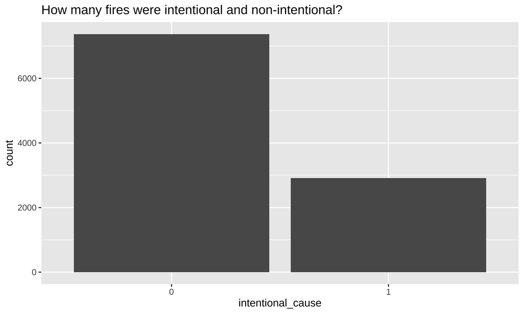

```r
ggplot(final_data, aes(x=intentional_cause)) + geom_bar() +
  ggtitle("How many fires were intentional and non-intentional?")
```

What’s the distribution of the fires according to the season?

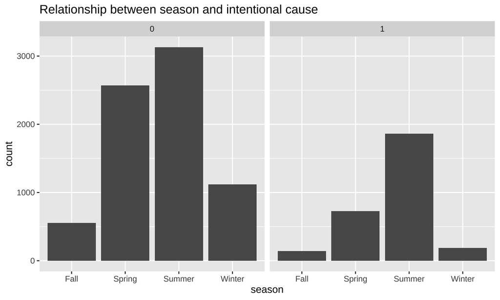

```r
ggplot(final_data, aes(x=season)) + geom_bar() + facet_wrap(~intentional_cause) +
  ggtitle("Relationship between season and intentional cause")
```

Could there be a relationship between “intentional_cause” and the maximum temperature?

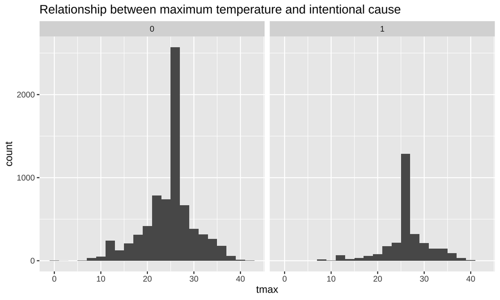

```r
ggplot(final_data, aes(x=tmax)) + geom_histogram(binwidth = 2) +
  facet_wrap(~intentional_cause) +
  ggtitle("Relationship between maximum temperature and intentional cause")
```

Could there be a relationship between “intentional_cause” and the time it was alerted?

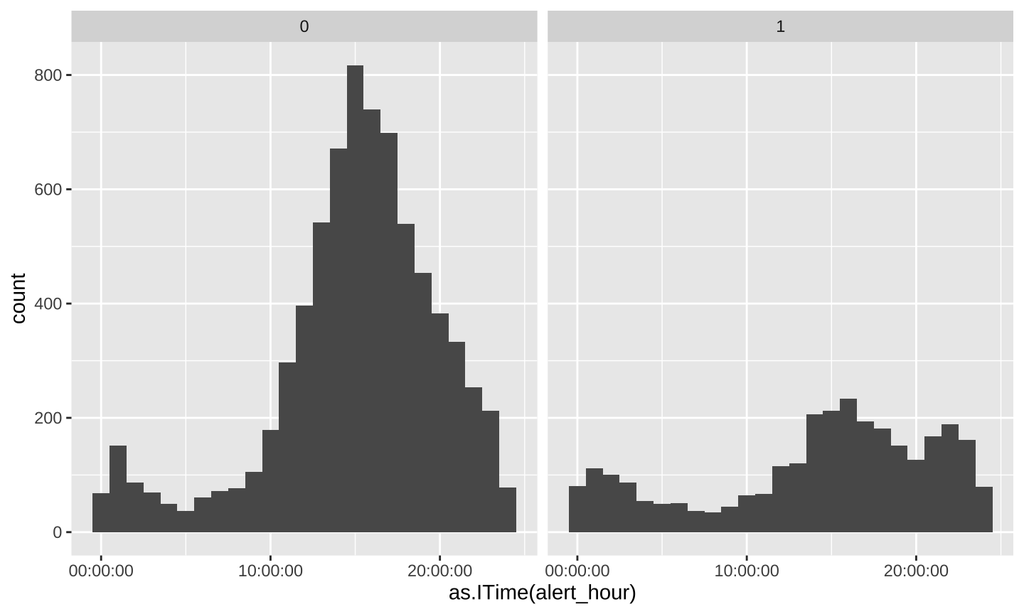

```r
ggplot(final_data, aes(x=as.ITime(alert_hour))) + geom_histogram(binwidth = 3600) +
  scale_x_time() + facet_wrap(~intentional_cause)
```

What can we say about the “origin” and the “intentional_cause”?

```r
final_data %>% group_by(origin,intentional_cause) %>% count() %>%
  arrange(desc(n))
```

```
## # A tibble: 8 × 3
## # Groups:   origin, intentional_cause [8]
##   origin      intentional_cause     n
##   <fct>       <fct>             <int>
## 1 firepit     0                  3874
## 2 firepit     1                  1895
## 3 agriculture 0                  1727
## 4 fire        0                  1282
## 5 fire        1                   675
## 6 agric_burn  0                   490
## 7 agriculture 1                   344
## 8 agric_burn  1                     3
```

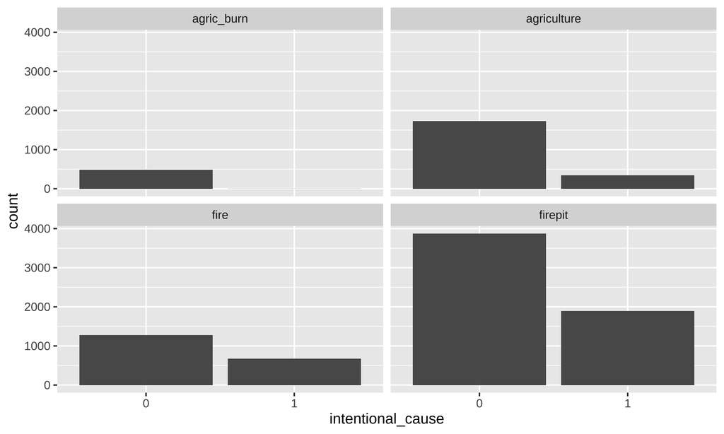

```r
ggplot(final_data, aes(x=intentional_cause)) + geom_bar() + facet_wrap(~origin)
```

We can see in the graph that the most fires with “intentional_cause” have origin “firepit”.

Relationship between “tmax”, “origin” and “intentional_cause”

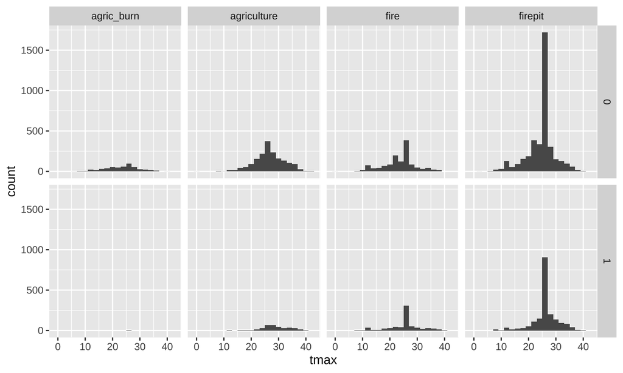

```r
ggplot(final_data, aes(x=tmax)) + geom_histogram(binwidth = 2) +
  facet_grid(intentional_cause~origin)
```

Is there a relationship between the area damaged and intentional_cause?

```r
final_data %>% group_by(intentional_cause) %>%
  summarise(total_area_mean=mean(total_area),
            total_area_median=median(total_area))
```

```
## # A tibble: 2 × 3
##   intentional_cause total_area_mean total_area_median
##   <fct>                       <dbl>             <dbl>
## 1 0                            3.94             0.1
## 2 1                            7.44             0.141
```

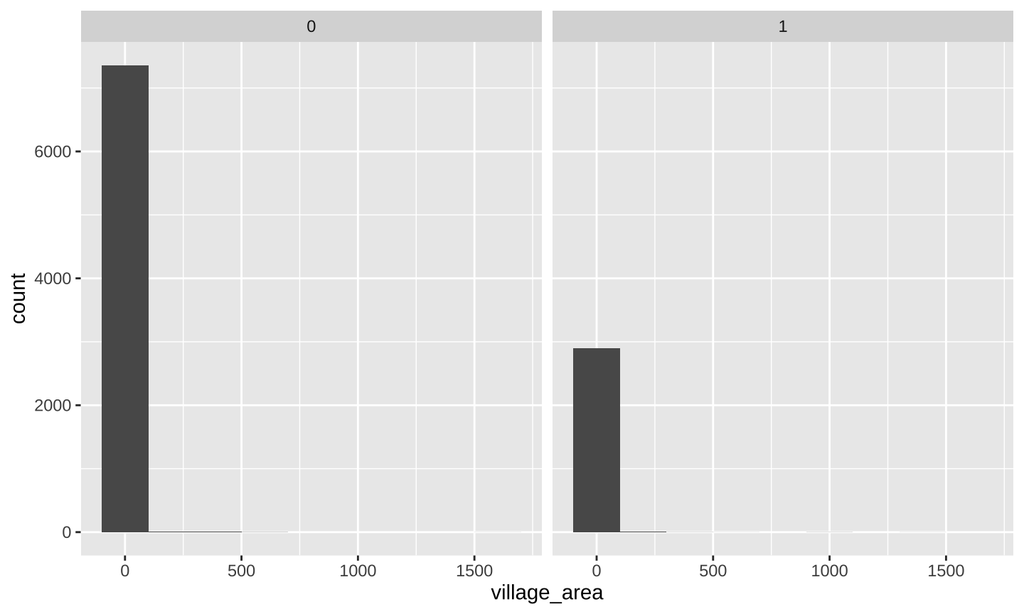

```r
ggplot(final_data, aes(x=village_area)) + geom_histogram(binwidth = 200) +
  facet_wrap(~intentional_cause)
```

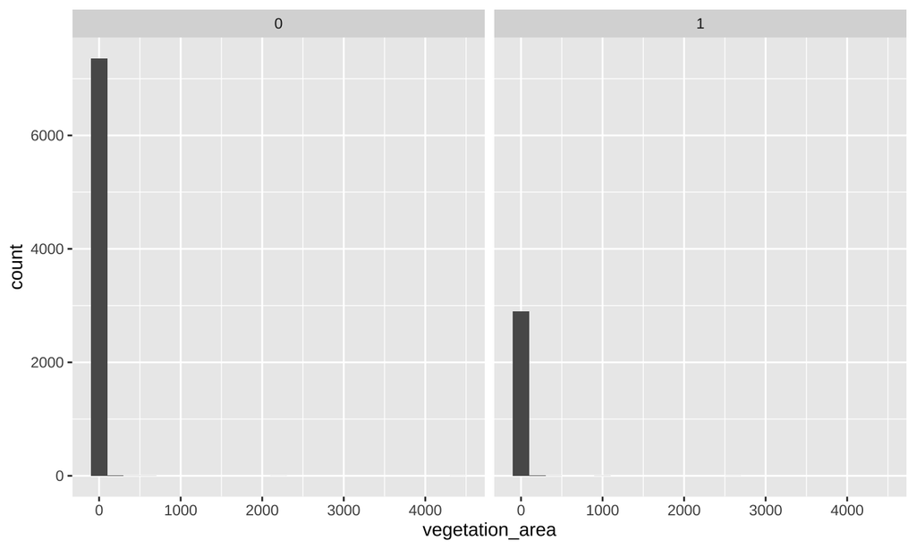

```r
ggplot(final_data, aes(x=vegetation_area)) + geom_histogram(binwidth = 200) +
  facet_wrap(~intentional_cause)
```

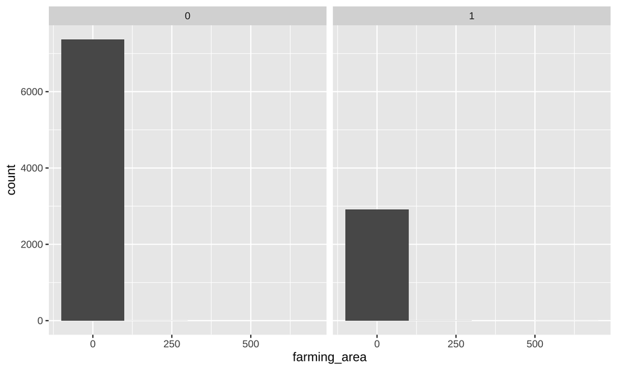

```r
ggplot(final_data, aes(x=farming_area)) + geom_histogram(binwidth = 200) +
  facet_wrap(~intentional_cause)
```

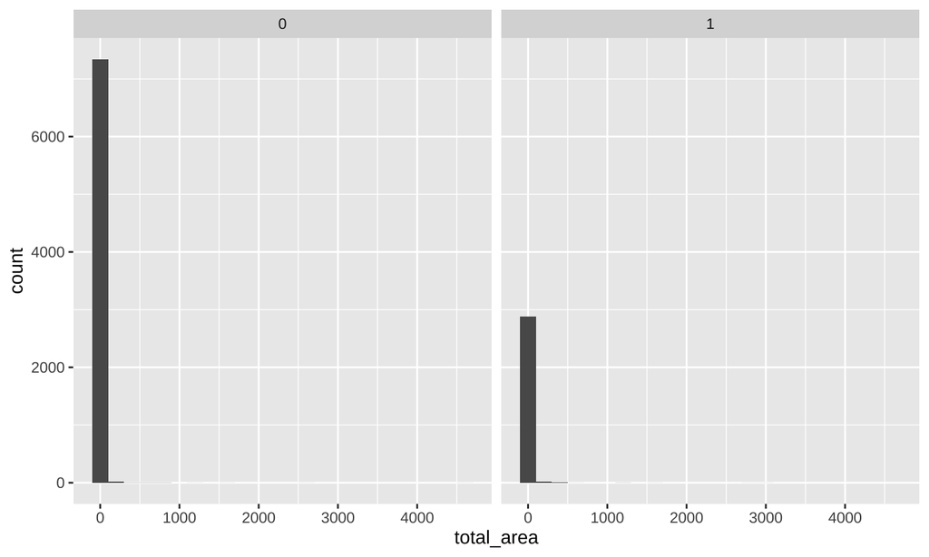

```r
ggplot(final_data, aes(x=total_area)) + geom_histogram(binwidth = 200) +
  facet_wrap(~intentional_cause)
```

What is the correlation coefficient between all numeric attributes?

```r
final_data %>% select(tmax,village_area, farming_area,
                 vegetation_area, total_area) %>% cor()
```

```
##                       tmax village_area farming_area vegetation_area total_area
## tmax            1.00000000   0.03306656   0.05716091      0.02483908 0.03724981
## village_area    0.03306656   1.00000000   0.52373335      0.30648711 0.67845978
## farming_area    0.05716091   0.52373335   1.00000000      0.20320156 0.45332400
## vegetation_area 0.02483908   0.30648711   0.20320156      1.00000000 0.90340276
## total_area      0.03724981   0.67845978   0.45332400      0.90340276 1.00000000
```

Is there any monotonic relationship?

```r
final_data %>% select(tmax,village_area, farming_area,
                 vegetation_area, total_area) %>% cor(method = "spearman")
```

```
##                        tmax village_area farming_area vegetation_area
## tmax             1.00000000  -0.02887639    0.1922208     -0.17637656
## village_area    -0.02887639   1.00000000   -0.2432814     -0.06095513
## farming_area     0.19222078  -0.24328140    1.0000000     -0.51526703
## vegetation_area -0.17637656  -0.06095513   -0.5152670      1.00000000
## total_area      -0.07438315   0.41310067   -0.0493272      0.47420921
##                  total_area
## tmax            -0.07438315
## village_area     0.41310067
## farming_area    -0.04932720
## vegetation_area  0.47420921
## total_area       1.00000000
```

##Clustering

In order to Clustering we need to pass to the new data set (called “data_cluster”) the relevant attributes.

We believe the relevant attributes are “tmax”, “village_area”, “vegetation_area” and “farming_area”. Note that we didn’t include “total_area” because it is a linear combination of the last 3 attributes mentioned above.

```r
data_cluster <- final_data %>% select(tmax,village_area,vegetation_area,
                                      farming_area)
```

Given that the data has different scales, we decided to use the scale() function:

```r
data_cluster.scale <- data_cluster %>% mutate_all(scale)
```

### K-MEANS Algorithm

Calculating the optimal number of cluster (k) through silhouette method and also plotting the result:

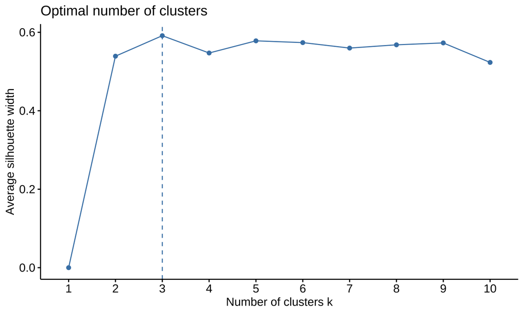

```r
fviz_nbclust(data_cluster.scale, kmeans, method = "silhouette")
```

We got k=3 as the optimal number of clusters.

Now we’ll perform K-means algorithm with k=3:

```r
k3 <- kmeans(data_cluster.scale, centers=3)
```

Plotting the clusters:

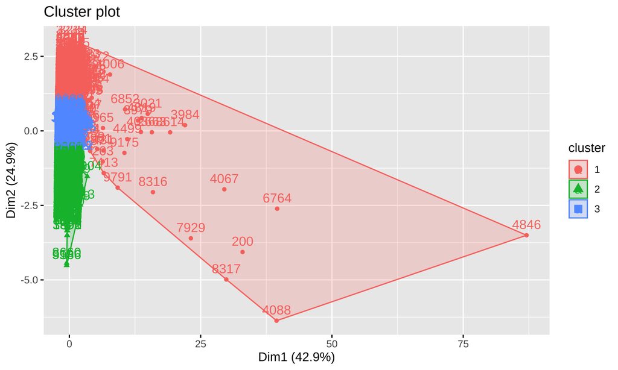

```r
fviz_cluster(k3, data_cluster.scale)
```

[output not shown]